# The beast of BIAS

Klinkenberg

27 sep 2018

## What is BIAS

Things that lead us to the wrong conclusions (Field)

$$outcome_i = model_i + error_i$$
$$model_i = b_1 X_{1i} + b_2 X_{2i} + \ldots + b_n X_{ni}$$

- $X$ = predictor variables
- $b$ = parameters

## BIAS

Wrong conclusions about:

- Parameters $b_i$
- Standaard error and confidence intervals
- Test statistics and $p$-values

means → SE → CI

SE → test statistics → $p$-values

## The beasts

[figure not shown]

> - Outliers
> - Violations of assumptions

## Example

IQ estimations of males and febecouse. We want to know the differences in the population not the sample. We therefore want to make an inference about the population, hence the name inferential statistics.

```r
data = read.table("../../topics/t-test_independent/IQ.csv", sep = ' ', header = T)
names(data)[3] <- "male"
data$male <- ifelse(data$male == "male" , 1, 0)
data[12:15,]
```

```
##    IQ.next.to.you IQ.you male
## 12            125    125    1
## 13            115    111    1
## 14             60    160    0
## 15            115    115    1
```

We can see that fameles are coded as 0 and males as 1. Such coding can be used in a linear regression equation.

$$\text{IQ you}_i = b_0 + b_1 male_i + error_i$$

```r
means <- aggregate(IQ.you ~ factor(male), data, mean); means
```

```
##   factor(male)   IQ.you
## 1            0 123.6735
## 2            1 118.9821
```

We can now calculate the $b$’s: $b_0 = 123.67$ and $b_1 = -4.69$

$$\text{IQ you}_i = b_0 + b_1 male_i + error_i$$

If we apply this to the regression model we get:

```
##         b.0   b.1 male  model IQ.you  error
## [1,] 123.67 -4.69    0 123.67    120  -3.67
## [2,] 123.67 -4.69    1 118.98    120   1.02
## [3,] 123.67 -4.69    0 123.67    120  -3.67
## [4,] 123.67 -4.69    1 118.98    110  -8.98
## [5,] 123.67 -4.69    0 123.67    110 -13.67
## [6,] 123.67 -4.69    1 118.98    119   0.02
## [7,] 123.67 -4.69    1 118.98    128   9.02
## [8,] 123.67 -4.69    0 123.67    104 -19.67
```

The means indirectly represent the parameters $b$’s in this regression model. These $b$’s are the estimates of the population parameters $\beta$’s.

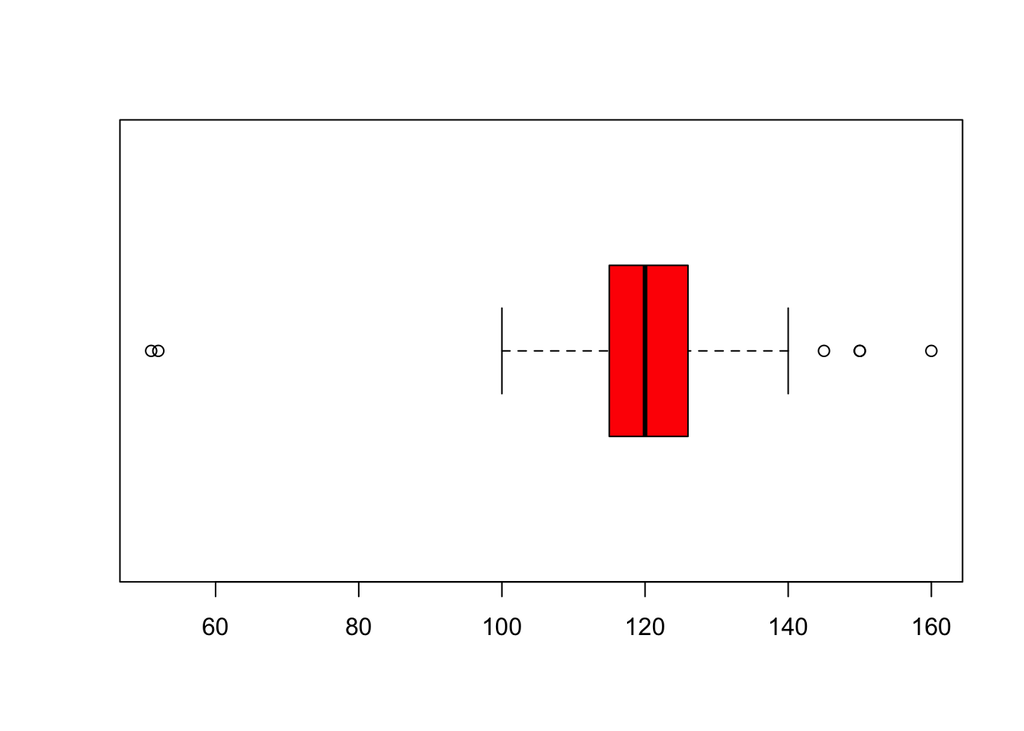

But what if these means are not correct, because of an extreme outlier.

## Outliers

Outliers can have a huge impact on the estimations

- **Trim** Delete based on boxplot.
- **Trim** Delete based on 3 standard deviations.
- **Trim** Trimmed mean: Delete upper and lower percentages.
- **Winsorizing** Replace outliers with highest non outlier.

Without these outliers the results look a bit different.

```
##   factor(male)   IQ.you
## 1            0 121.3333
## 2            1 121.1224
```

```
##    IQ.you      b.0        b.1 male      error
## 12    125 121.3333 -0.2108844    1   3.877551
## 13    111 121.3333 -0.2108844    1 -10.122449
## 15    115 121.3333 -0.2108844    1  -6.122449
## 16    110 121.3333 -0.2108844    0 -11.333333
## 17    125 121.3333 -0.2108844    0   3.666667
## 18    139 121.3333 -0.2108844    0  17.666667
```

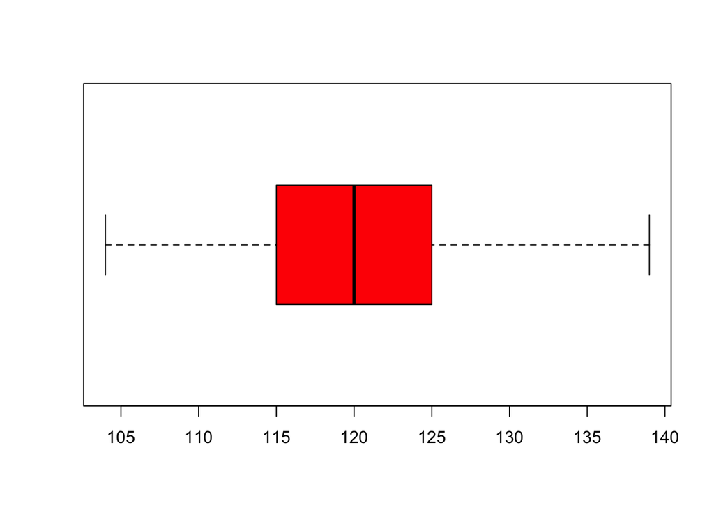

## Assumptions

- Additivity and linearity
- Normality
- Homoscedasticity/homogenity of variance
- Independence

## Additivity and linearity

The outcome variable is linearly related to the predictors.

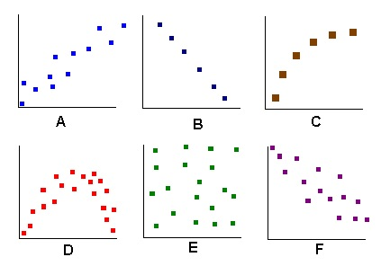

relations

$$\text{MODEL}_i = b_1 X_{1i} + b_2 X_{2i} + \ldots + b_n X_{ni}$$

## Additivity and linearity

We can check this by looking at the scatterplot of the predictors with the outcome variable.

## Normality

Not the normality of the sample but the normality of the parameter $\beta$ in the population. We will test this assumption based on the data, though with large samples the [centrel limit theorem](https://youtu.be/JNm3M9cqWyc) ensures that the parameters are bell shaped.

## Centrel limit theorem

[video not shown]

## Normality

You can look at:

- Skewness and Kurtosis

We can test with:

- Kolmogorov-Smirnof test
- Shapiro-Wilk test

- We can also transform the variable

## Homoscedasticity/homogenity of variance

Influences:

- Parameters $b$’s
- NHT

The null hypothesis assumes the null distribution to be true. Therefore, different sampples from that districution should have equal variances. Otherwise the assumption could not hold.

In general, we can say that on every value of the predictor variable the variances in the outcome variable should be equal.

We can check this by plotting the standardised error/resiual and the standardised expected outcome/model.

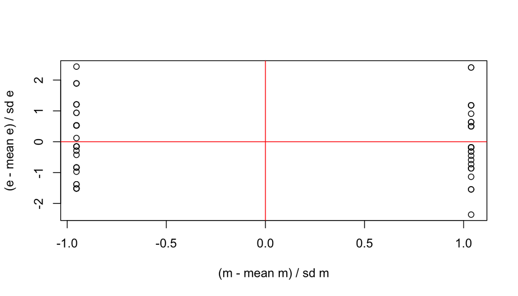

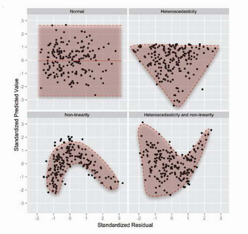

Lineairiteit

[video not shown]

## Independence

The observed outcome (rows in SPSS or participants in your research) should be independent from each other. The answer of person B should not depend on the answer of person A.

[figure not shown]

Whisper

# End

- [@shklinkenberg](https://twitter.com/shklinkenberg)
- [Klinkenberg](https://www.linkedin.com/in/sharonklinkenberg/)
- ln.AvU@grebneknilK.S
- ShKlinkenberg